# Прогнозирование

Евгений Смирнов, 274 группа

May 12, 2016

## Задание

- Визуализировать данные, проанализировать распределения признака (оценить необходимость трансформации), оценить наличие выбросов, преобразования для снятия календарных эффектов;
- Настроить модели ARIMA:
- выбрать модель руками на основании анализа ACF/PACF, произвести поиск наилучшей модели в окрестности, выполнить анализ остатков
- автоматический способом подбора модели, проверить её соответствие особенностями ряда, сделать анализ остатков;
- Настроить модель экспоненциального сглаживания автоматическим методом подбора модели, проверить её соответствие особенностям ряда, выполнить корректировку, произвести анализ остатков;
- Выполнить визуальный анализ, при необходимости — формальную проверку наличия структурных изменений в моделях;
- Сравнить и выбрать лучшую модель по критерию Диболда-Мариано;

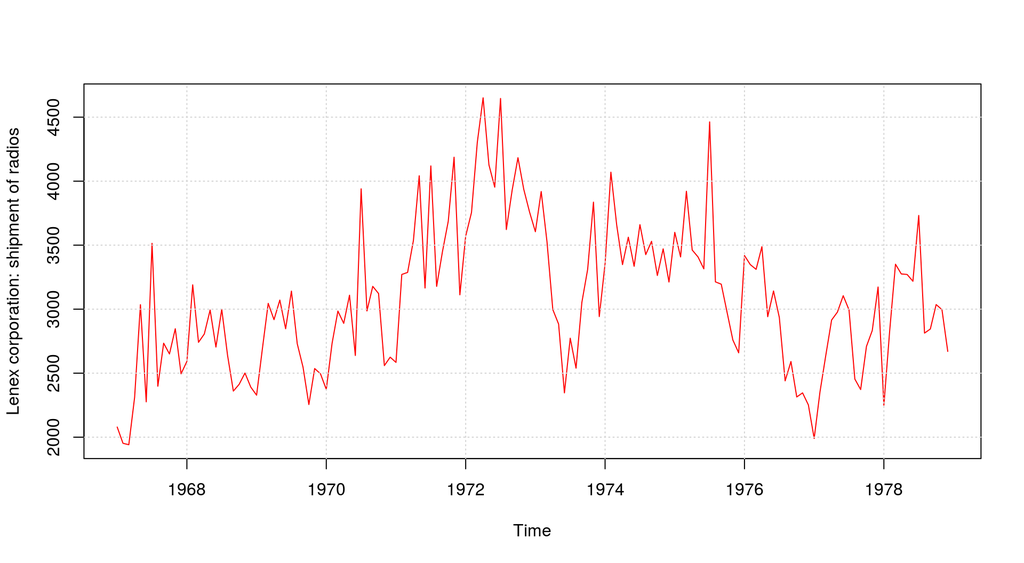

```r
library(forecast)
library(tseries)
library(lmtest)
library(Hmisc)
data = read.csv("lenex-corporation-shipment-of-ra.csv", header = T, stringsAsFactors = F)
names(data)[1] <- "Date"
names(data)[2] <- "Value"
xname <- "Lenex corporation: shipment of radios"

data$Value <- as.numeric(data$Value)
data$Date <- as.Date(as.yearmon(data$Date, format="%Y-%m"))
tSeries <- ts(data = data$Value, start = as.numeric(c(format(data$Date[1], "%Y"), format(data$Date[1], "%m"))), freq = 12)
plot(tSeries, type="l", ylab=xname, col="red")
grid()
```

```r
trainSeries <- window(tSeries, end=c(1976,01))
testSeries  <- window(tSeries, start=c(1976,2))
D = 36
```

Попробуем поделить на число дней в месяце:

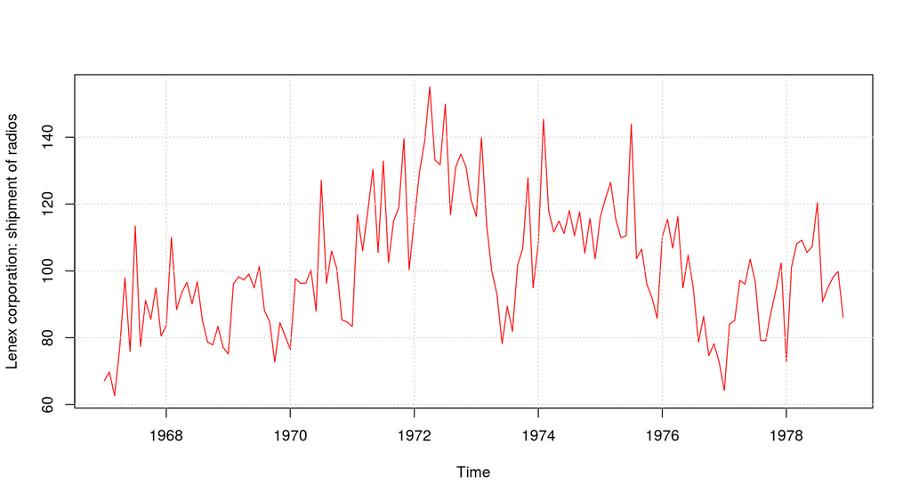

```r
plot(tSeries / monthDays(as.Date(time(tSeries))), type="l", ylab=xname, col="red")
grid()
```

Ряд не стал более регулярным, так что вернёмся к исходным данным.

STL-декомпозиция ряда:

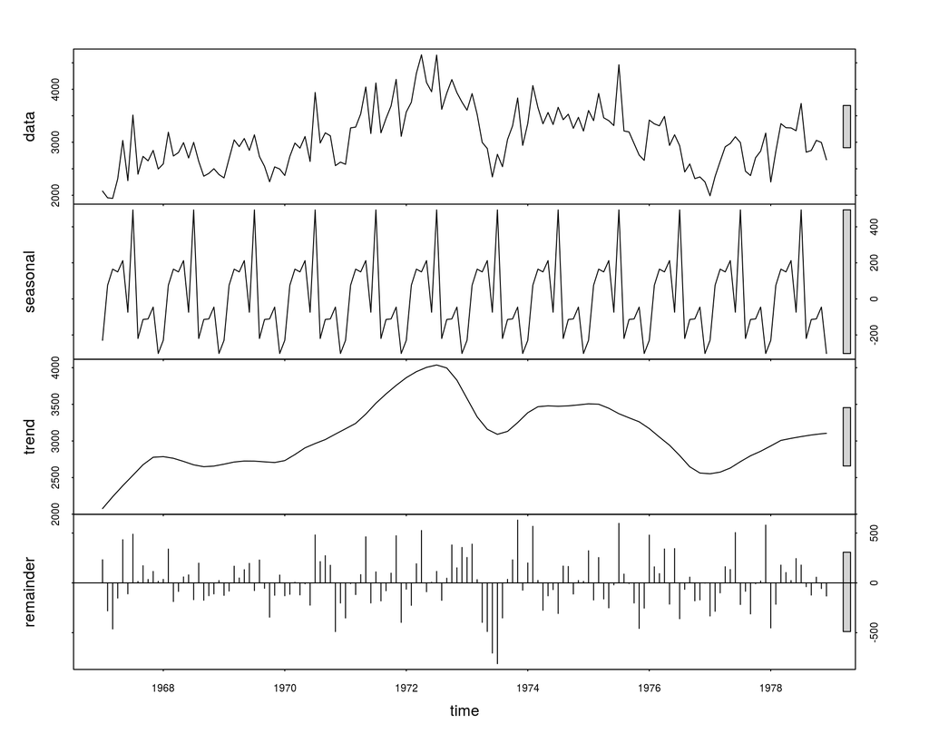

```r
plot(stl(tSeries, s.window="periodic"))
```

Оптимальное преобразование Бокса-Кокса и результат его применения:

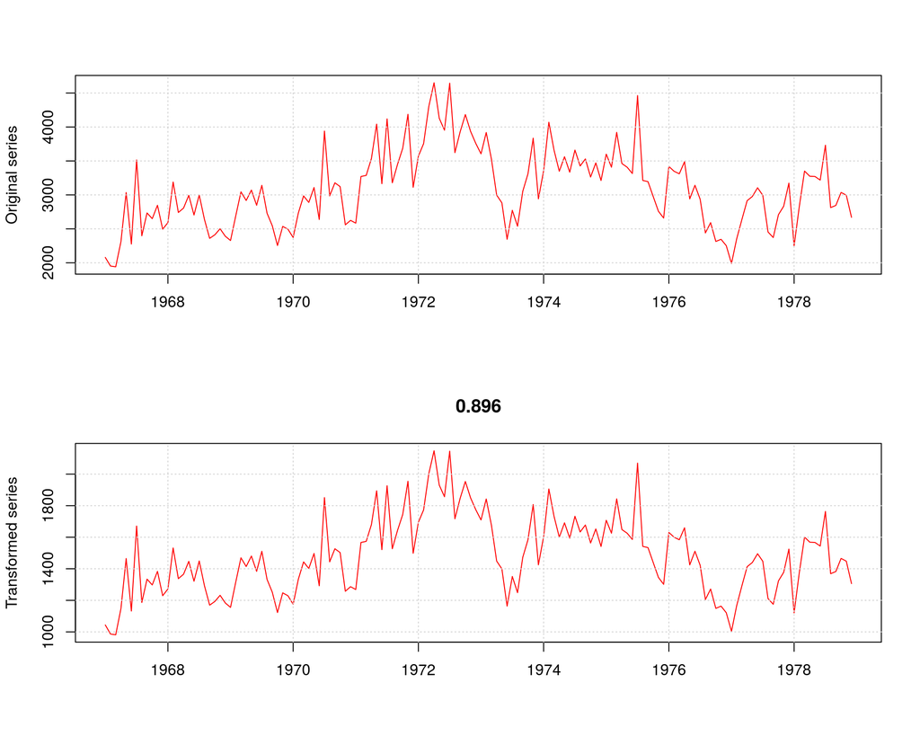

```r
par(mfrow=c(2,1))
plot(tSeries, ylab="Original series", xlab="", col="red")
grid()

LambdaOpt <- BoxCox.lambda(tSeries)
plot(BoxCox(tSeries, LambdaOpt), ylab="Transformed series", xlab="", col="red")
title(main=toString(round(LambdaOpt, 3)))
grid()
```

Преобразование стабилизирует дисперсию, будем его использовать.

## Прогноз ETS

```r
fit.ets <- ets(tSeries, lambda = LambdaOpt)
print(fit.ets)
```

```
## ETS(A,N,A)
##
## Call:
##  ets(y = tSeries, lambda = LambdaOpt)
##
##   Box-Cox transformation: lambda= 0.8955
##
##   Smoothing parameters:
##     alpha = 0.5921
##     gamma = 1e-04
##
##   Initial states:
##     l = 1302.2203
##     s=-125.9989 -25.6592 -49.6367 -46.5272 -95.8293 206.8232
##            -26.8302 88.7326 72.7413 83.8722 46.8441 -128.5319
##
##   sigma:  135.8792
##
##      AIC     AICc      BIC
## 2158.242 2161.498 2199.819
```

Настроив выбранную модель на обучающей выборке, посчитаем её качество на тестовой:

```
##                       ME     RMSE      MAE         MPE      MAPE      MASE
## Training set    9.419433 313.6478 259.9723  -0.3476657  8.429955 0.5541293
## Test set     -561.772133 670.0756 569.9007 -21.6990664 21.954290 1.2147396
##                     ACF1 Theil's U
## Training set 0.005622902        NA
## Test set     0.355754414   2.16716
```

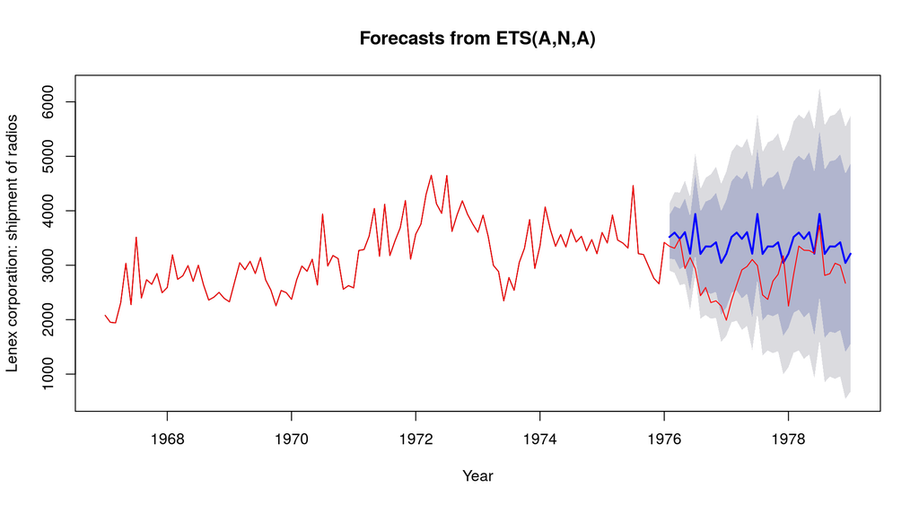

Остатки:

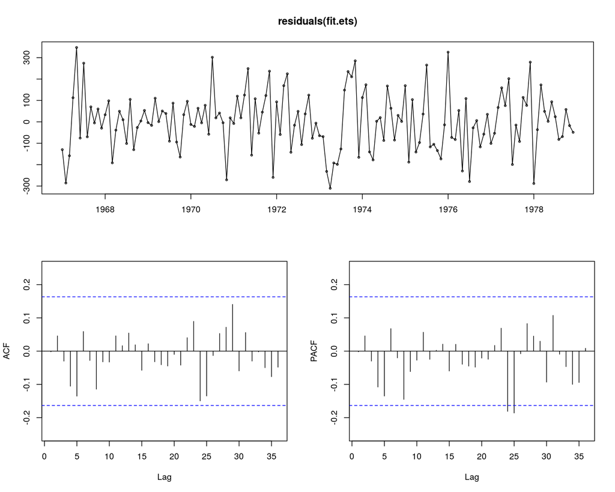

```r
tsdisplay(residuals(fit.ets))
```

Достигаемые уровни значимости критерия Льюнга-Бокса для них:

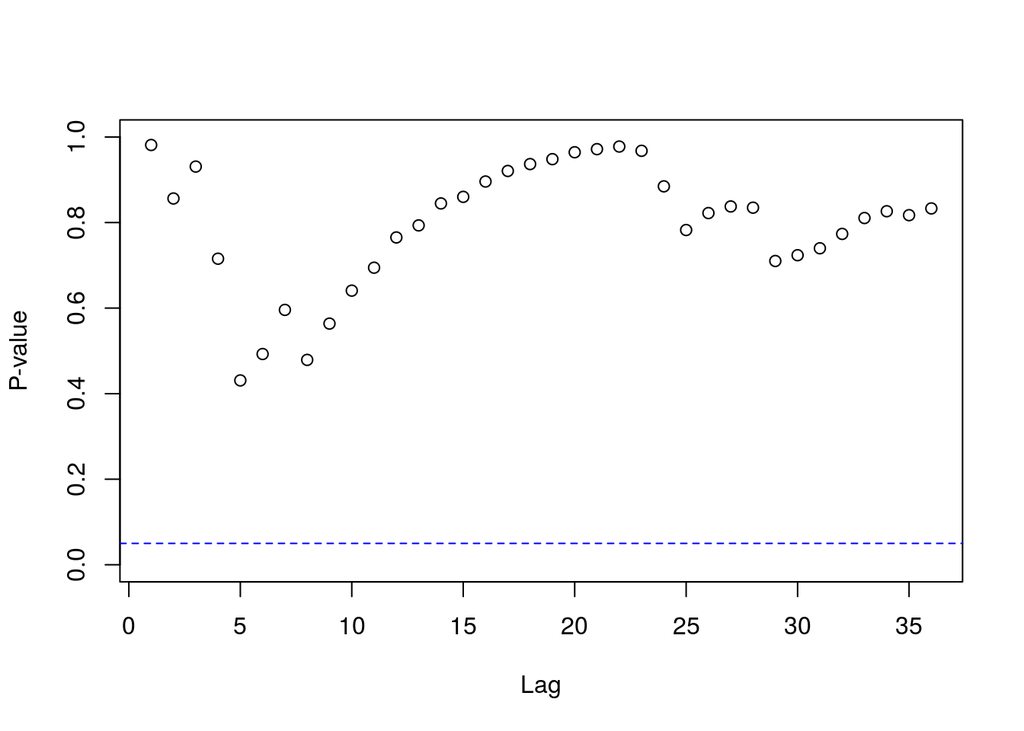

```r
p <- rep(0, 1, frequency(tSeries)*3)
for (i in 1:length(p)){
  p[i] <- Box.test(residuals(fit.ets), lag=i, type = "Ljung-Box")$p.value
}
plot(p, xlab="Lag", ylab="P-value", ylim=c(0,1))
abline(h = 0.05, lty = 2, col = "blue")
```

Остатки некоррелированы.

Q-Q plot и гистограмма для остатков:

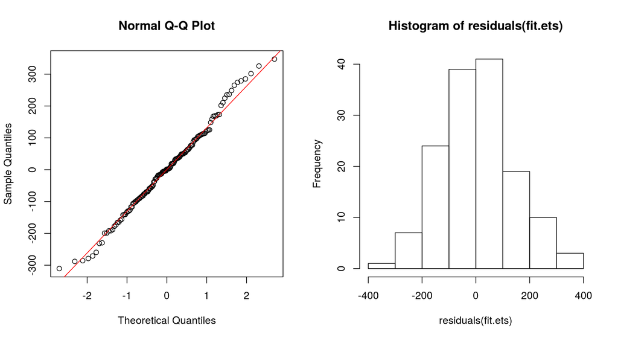

```r
par(mfrow=c(1,2))
qqnorm(residuals(fit.ets))
qqline(residuals(fit.ets), col="red")
hist(residuals(fit.ets))
```

У распределения нет тяжёлых хвостов.

| Гипотеза | Критерий | Результат проверки | Достигаемый уровень значимости |
| --- | --- | --- | --- |
| Нормальность | Шапиро-Уилка | не отвергается | 0.6015413 |
| Несмещённость | Уилкоксона | не отвергается | 0.9721592 |
| Стационарность | KPSS | не отвергается | 0.1 |
| Гомоскедастичность | Бройша-Пагана | не отвергается | 0.7951861 |

```r
res.ets  <- tSeries - fit.ets$fitted
```

## ARIMA

### Ручной подбор модели

Исходный ряд нестационарен (p<0.01, критерий KPSS); сделаем сезонное дифференцирование:

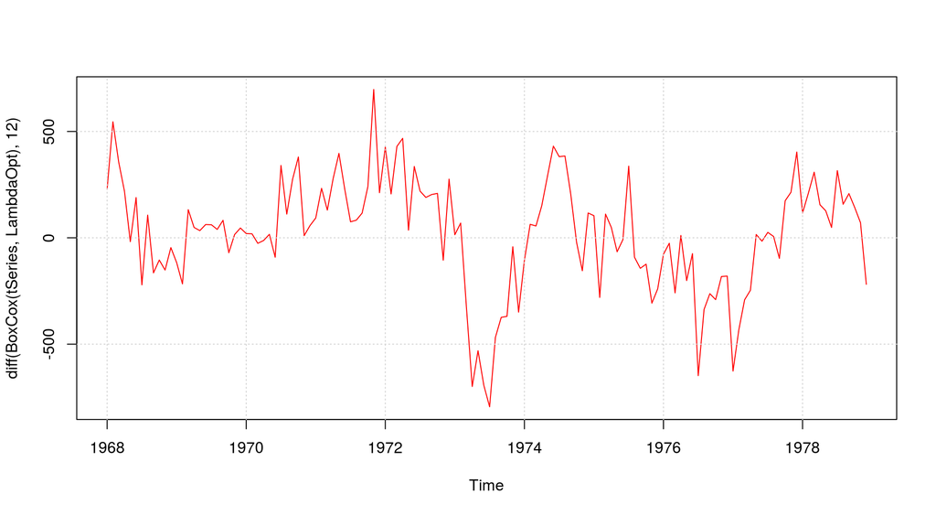

```r
plot(diff(BoxCox(tSeries, LambdaOpt), 12), type="l", col="red")
grid()
```

Для полученного ряда гипотеза стационарности не отвергается (p = 0.0888041)

Посмотрим на ACF и PACF полученного продифференцированного ряда:

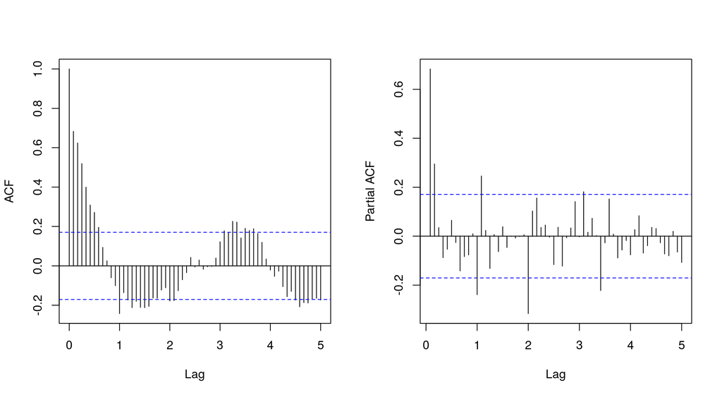

```r
par(mfrow=c(1,2))
acf(diff(BoxCox(tSeries, LambdaOpt), 12), lag.max=5*12, main="")
pacf(diff(BoxCox(tSeries, LambdaOpt), 12), lag.max=5*12, main="")
```

Будем искать модель в окрестности ARIMA(2,0,6)(2,1,1)$_{12}$

| Модель | AICc |
| --- | --- |
| ARIMA(2,0,6)(2,1,1)$_{12}$ | 1724.144489 |
| ARIMA(1,0,6)(2,1,1)$_{12}$ | 1722.1974255 |
| ARIMA(2,0,5)(2,1,1)$_{12}$ | 1723.0847584 |
| ARIMA(2,0,6)(2,1,0)$_{12}$ | 1732.6579244 |
| ARIMA(2,0,6)(1,1,1)$_{12}$ | 1722.2464014 |
| ARIMA(2,0,7)(2,1,0)$_{12}$ | 1734.969046 |
| ARIMA(2,0,6)(2,1,2)$_{12}$ | 1725.5704316 |
| ARIMA(2,0,6)(3,1,0)$_{12}$ | 1735.157409 |
| ARIMA(1,0,5)(2,1,1)$_{12}$ | 1721.7222861 |
| ARIMA(2,0,6)(1,1,0)$_{12}$ | 1746.1814764 |
| ARIMA(2,0,5)(1,1,1)$_{12}$ | 1721.5084937 |
| ARIMA(1,0,6)(1,1,1)$_{12}$ | 1720.3752995 |
| ARIMA(2,0,6)(0,1,1)$_{12}$ | 1721.2200363 |
| ARIMA(3,0,6)(0,1,1)$_{12}$ | 1758.2914484 |
| ARIMA(2,0,7)(0,1,1)$_{12}$ | 1722.4784063 |
| ARIMA(2,0,6)(0,1,2)$_{12}$ | 1721.9726715 |

Возьмём модель ARIMA(1,0,6)(1,1,1)$_{12}$, как модель с наименьшим AIC.

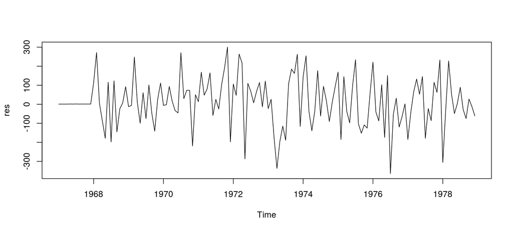

```r
fit <- Arima(tSeries, order=c(1,0,6), seasonal=c(1,1,1), lambda=LambdaOpt)
res <- residuals(fit)
plot(res)
```

Видно, что в начале ряда остатки не определены, что логично, поскольку модель сезонная. Отрежем начало ряда остатков и проанализируем их:

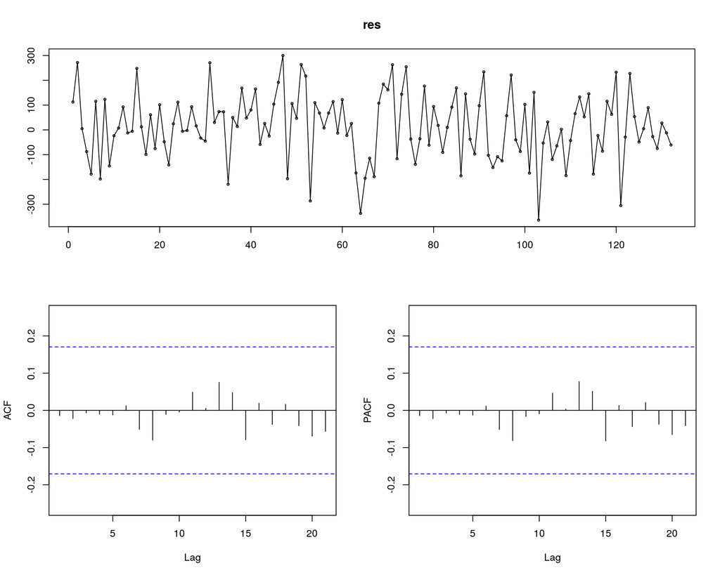

```r
res <- res[-c(1:12)]
tsdisplay(res)
```

Достигаемые уровни значимости критерия Льюнга-Бокса для остатков:

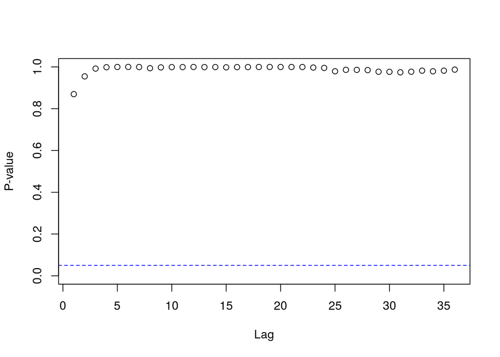

```r
p <- rep(0, 1, frequency(tSeries)*3)
for (i in 1:length(p)){
  p[i] <- Box.test(res, lag=i, type = "Ljung-Box")$p.value
}
plot(p, xlab="Lag", ylab="P-value", ylim=c(0,1))
abline(h = 0.05, lty = 2, col = "blue")
```

Q-Q plot и гистограмма:

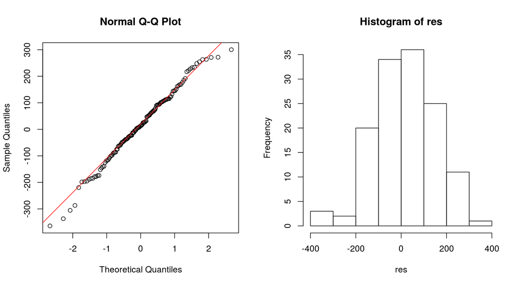

| Гипотеза | Критерий | Результат проверки | Достигаемый уровень значимости |
| --- | --- | --- | --- |
| Нормальность | Шапиро-Уилка | не отвергается | 0.4651276 |
| Несмещённость | Уилкоксона | не отвергается | 0.1769283 |
| Стационарность | KPSS | не отвергается | 0.1 |
| Гомоскедастичность | Бройша-Пагана | не отвергается | 0.7915915 |

```r
par(mfrow=c(1,2))
qqnorm(res)
qqline(res, col="red")
hist(res)
```

Настроив выбранную модель на обучающей выборке, посчитаем её качество на тестовой:

```r
fitShort <- Arima(trainSeries, order=c(1,0,6), seasonal=c(1,1,1), lambda=LambdaOpt)
fc       <- forecast(fitShort, h=D)
accuracy(fc, testSeries)
```

```
##                      ME     RMSE      MAE         MPE      MAPE      MASE
## Training set   27.48649 305.1048 235.3707   0.3768768  7.269806 0.5016912
## Test set     -540.18226 649.8681 554.3452 -20.8518303 21.296544 1.1815830
##                     ACF1 Theil's U
## Training set 0.002947568        NA
## Test set     0.327112750  2.096281
```

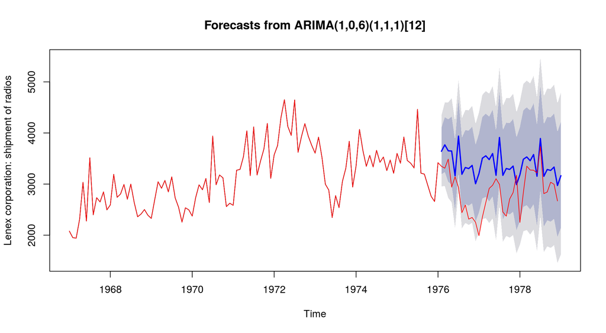

```r
plot(forecast(fitShort, h=D), ylab=xname, xlab="Time")
lines(tSeries, col="red")
```

### Автоматический подбор модели

Применим функцию auto.arima:

```r
fit.auto <- auto.arima(tSeries, lambda = LambdaOpt)
fit.auto
```

```
## Series: tSeries
## ARIMA(1,1,0)(2,0,0)[12]
## Box Cox transformation: lambda= 0.8955062
##
## Coefficients:
##           ar1    sar1    sar2
##       -0.4361  0.3492  0.1327
## s.e.   0.0766  0.0863  0.0894
##
## sigma^2 estimated as 25402:  log likelihood=-927.97
## AIC=1863.94   AICc=1864.23   BIC=1875.79
```

Предлагается модель ARIMA(1,1,0)(2,0,0)$_{12}$. Её AICc выше, чем у модели, подобранной вручную. Посмотрим на её остатки:

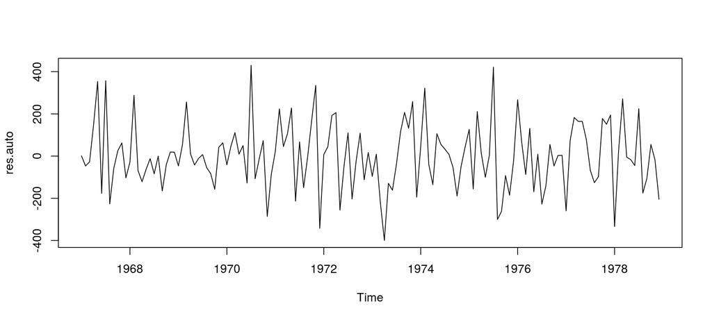

```r
res.auto <- residuals(fit.auto)
plot(res.auto)
```

Посмотрим на её остатки:

[figure not shown]

```r
res.auto <- residuals(fit.auto)
plot(res.auto)
```

Отрежем первые 13 отсчётов и продолжим анализ:

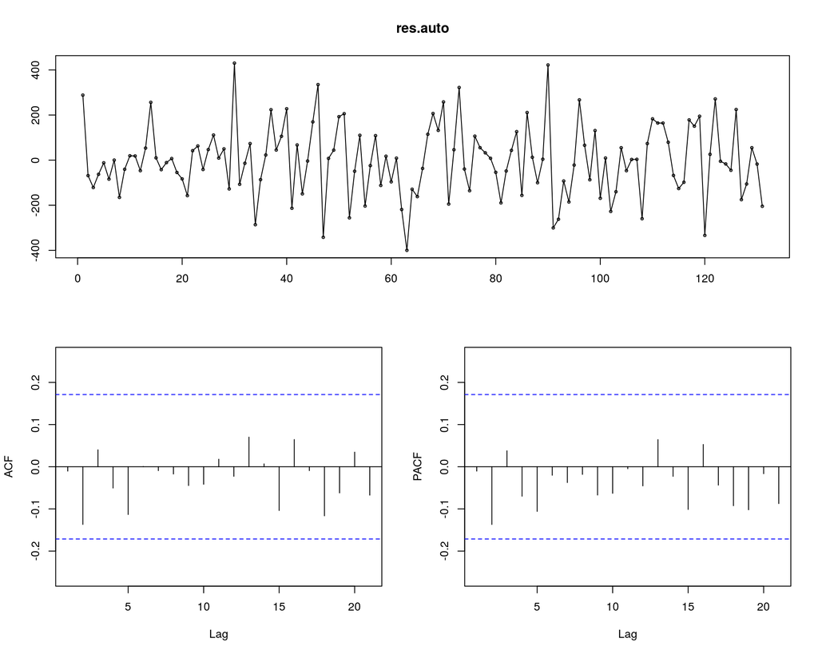

```r
res.auto <- res.auto[-c(1:13)]
tsdisplay(res.auto)
```

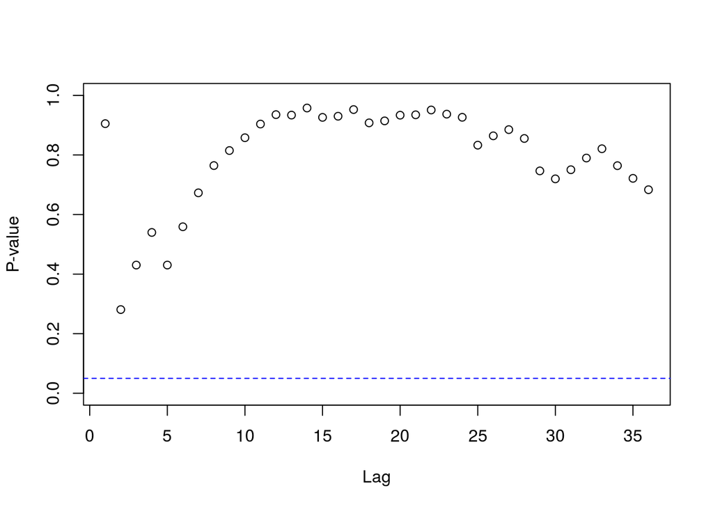

```r
p <- rep(0, 1, frequency(tSeries)*3)
for (i in 1:length(p)){
  p[i] <- Box.test(res.auto, lag=i, type = "Ljung-Box")$p.value
}
plot(p, xlab="Lag", ylab="P-value", ylim=c(0,1))
abline(h = 0.05, lty = 2, col = "blue")
```

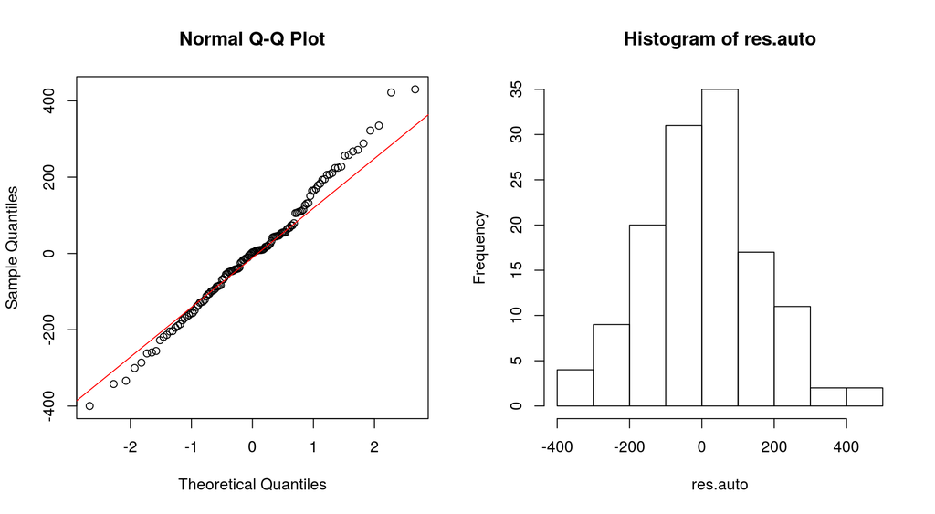

| Гипотеза | Критерий | Результат проверки | Достигаемый уровень значимости |
| --- | --- | --- | --- |
| Нормальность | Шапиро-Уилка | не отвергается | 0.7281695 |
| Несмещённость | Уилкоксона | не отвергается | 0.8317216 |
| Стационарность | KPSS | не отвергается | 0.1 |
| Гомоскедастичность | Бройша-Пагана | не отвергается | 0.393022 |

```r
par(mfrow=c(1,2))
qqnorm(res.auto)
qqline(res.auto, col="red")
hist(res.auto)
```

Остатки автоматической модели не лучше, а её AICc больше, так что остановимся на модели, подобранной вручную.

Настроив выбранную модель на обучающей выборке, посчитаем её качество на тестовой:

```r
fitShort <- Arima(trainSeries, order=c(1,1,0), seasonal=c(2,0,0), lambda=LambdaOpt)
fc       <- forecast(fitShort, h=D)
accuracy(fc, testSeries)
```

```
##                       ME     RMSE      MAE         MPE      MAPE      MASE
## Training set    4.542445 373.0510 279.9277  -0.6329901  8.739278 0.5966641
## Test set     -257.946188 476.4845 380.7574 -11.2118739 14.850590 0.8115819
##                     ACF1 Theil's U
## Training set -0.05175723        NA
## Test set      0.51650147  1.547666
```

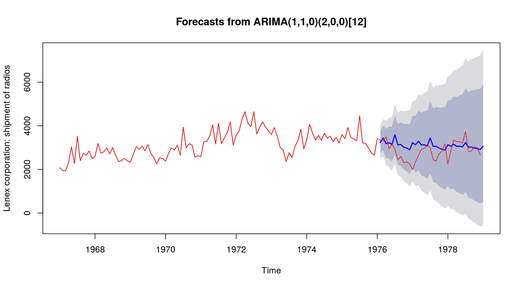

```r
plot(forecast(fitShort, h=D), ylab=xname, xlab="Time")
lines(tSeries, col="red")
```

Сравним остатки двух версий аримы, одинаково обрезав их начало так, чтобы у обоих методов они были правильно определены:

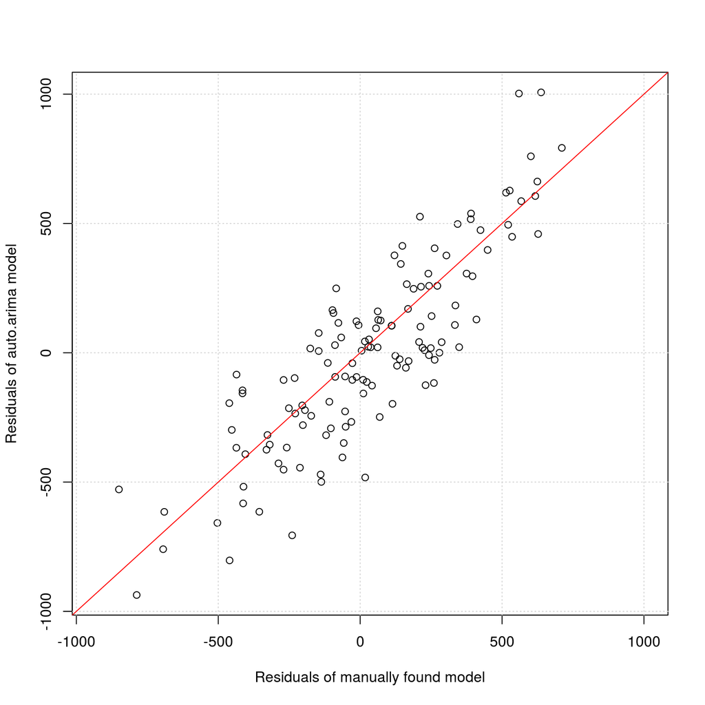

```r
res      <- (tSeries - fitted(fit))[-c(1:13)]
res.auto <- (tSeries - fitted(fit.auto))[-c(1:13)]

plot(res, res.auto, xlim=c(min(res, res.auto), max(res, res.auto)), ylim=c(min(res, res.auto), max(res, res.auto)),
     xlab = "Residuals of manually found model", ylab="Residuals of auto.arima model")
grid()
lines(c(min(res, res.auto), max(res, res.auto))*2, c(min(res, res.auto), max(res, res.auto))*2, col="red")
```

```r
dm.test(res, res.auto)
```

```
##
##  Diebold-Mariano Test
##
## data:  resres.auto
## DM = -2.7109, Forecast horizon = 1, Loss function power = 2,
## p-value = 0.007618
## alternative hypothesis: two.sided
```

```r
dm.test(res, res.auto, "less")
```

```
##
##  Diebold-Mariano Test
##
## data:  resres.auto
## DM = -2.7109, Forecast horizon = 1, Loss function power = 2,
## p-value = 0.003809
## alternative hypothesis: less
```

Согласно критерию Диболда-Мариано, прогнозы метода ARIMA c автоматически подобранными параметрами значимо менее точные, поэтому в качестве финального выберем прогноз найденной вручную аримы.

## Итоговое сравнение

Сравним остатки лучших моделей ARIMA и ETS, одинаково обрезав их начало так, чтобы у обоих методов они были правильно определены:

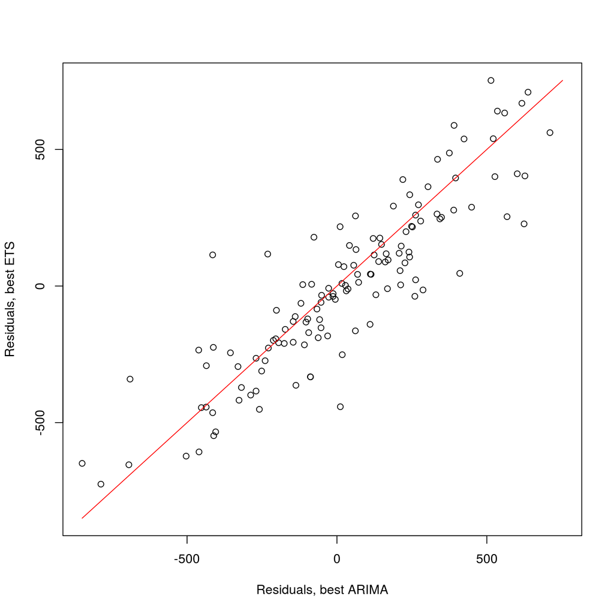

```r
res.ets <- (tSeries - fitted(fit.ets))[-c(1:13)]

plot(res, res.ets,
     xlab="Residuals, best ARIMA",
     ylab="Residuals, best ETS",
     xlim=c(min(c(res, res.ets), na.rm=T), max(c(res, res.ets), na.rm=T)),
     ylim=c(min(c(res, res.ets), na.rm=T), max(c(res, res.ets), na.rm=T)))
 lines(c(min(c(res, res.ets), na.rm=T), max(c(res, res.ets), na.rm=T)), c(min(c(res, res.ets), na.rm=T), max(c(res, res.ets), na.rm=T)), col="red")
```

```r
dm.test(res, res.ets)
```

```
##
##  Diebold-Mariano Test
##
## data:  resres.ets
## DM = 0.5545, Forecast horizon = 1, Loss function power = 2,
## p-value = 0.5802
## alternative hypothesis: two.sided
```

Согласно критерию Диболда-Мариано, прогнозы метода ARIMA не хуже, но AICc меньше, чем у модели ETS как и ошибка на тестовой выборке, значит будем использовать модель ARIMA, настроенную в ручную.

### Финальный прогноз

```r
fl <- forecast(fit, h=D)
print(fl)
```

```
##          Point Forecast    Lo 80    Hi 80    Lo 95    Hi 95
## Jan 1979       2699.471 2275.413 3130.633 2054.145 3361.475
## Feb 1979       3024.857 2538.058 3520.014 2284.157 3785.185
## Mar 1979       3149.496 2595.813 3713.589 2307.491 4015.966
## Apr 1979       3158.640 2558.888 3770.597 2247.067 4098.923
## May 1979       3230.083 2603.252 3869.962 2277.507 4213.357
## Jun 1979       2948.561 2315.824 3595.912 1987.798 3943.757
## Jul 1979       3514.399 2844.623 4197.857 2496.424 4564.560
## Aug 1979       2771.177 2101.181 3458.693 1754.998 3828.723
## Sep 1979       2873.373 2185.867 3578.662 1830.523 3958.201
## Oct 1979       2911.293 2211.112 3629.683 1849.274 4016.300
## Nov 1979       2965.679 2254.760 3695.022 1887.337 4087.516
## Dec 1979       2685.903 1976.029 3416.154 1610.314 3809.701
## Jan 1980       2737.695 2004.895 3491.813 1627.539 3898.301
## Feb 1980       3048.382 2294.642 3822.298 1905.461 4238.964
## Mar 1980       3149.153 2381.549 3937.000 1985.032 4361.078
## Apr 1980       3145.695 2369.525 3942.596 1968.735 4371.624
## May 1980       3219.704 2435.232 4024.856 2029.996 4458.246
## Jun 1980       2929.754 2149.867 3732.198 1748.183 4164.699
## Jul 1980       3500.869 2699.731 4321.789 2285.118 4763.279
## Aug 1980       2778.099 1994.996 3585.261 1592.520 4020.694
## Sep 1980       2888.021 2098.392 3701.142 1692.087 4139.578
## Oct 1980       2905.621 2113.271 3721.477 1705.528 4161.369
## Nov 1980       2970.934 2174.909 3790.142 1765.009 4231.722
## Dec 1980       2696.034 1908.077 3509.142 1503.698 3948.039
## Jan 1981       2749.881 1956.223 3568.538 1548.708 4010.339
## Feb 1981       3058.080 2251.679 3887.576 1836.200 4334.591
## Mar 1981       3155.216 2343.372 3989.717 1924.736 4439.264
## Apr 1981       3149.583 2336.008 3985.958 1916.534 4436.541
## May 1981       3223.400 2406.270 4062.982 1984.698 4515.166
## Jun 1981       2931.863 2123.113 3764.899 1707.109 4214.135
## Jul 1981       3503.291 2676.349 4351.321 2248.764 4807.587
## Aug 1981       2782.615 1977.353 3613.314 1563.925 4061.633
## Sep 1981       2893.176 2083.661 3727.367 1667.490 4177.328
## Oct 1981       2907.898 2097.719 3742.662 1681.139 4192.901
## Nov 1981       2974.309 2161.987 3810.769 1743.988 4261.783
## Dec 1981       2699.739 1896.975 3528.600 1485.298 3976.127
```

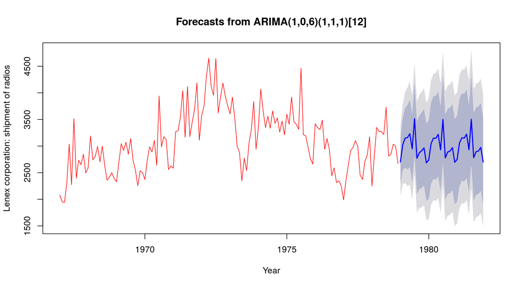

```r
plot(fl, ylab=xname, xlab="Year", col="red")
```